# exercise_classe

theSherrinford

07/07/2020

## R Markdown

This is an R Markdown document.

The goal of this project is to predict the manner in which they did the exercise. This is the “classe” variable in the training set. I will create a report describing how I have built my model, how I have used cross validation, what I think the expected out of sample error is, and why I have made the choices I did. I will also use your prediction model to predict 20 different test cases.

The training data for this project are available here: https://d396qusza40orc.cloudfront.net/predmachlearn/pml-training.csv The test data are available here: https://d396qusza40orc.cloudfront.net/predmachlearn/pml-testing.csv The data for this project come from this source: http://web.archive.org/web/20161224072740/http:/groupware.les.inf.puc-rio.br/har.

loading the required packages

```r
if(!require(tidyverse)) install.packages("tidyverse", repos = "http://cran.us.r-project.org")
if(!require(caret)) install.packages("caret", repos = "http://cran.us.r-project.org")
if(!require(readr)) install.packages("readr", repos = "http://cran.us.r-project.org")
if(!require(randomForest)) install.packages("randonForest", repos = "http://cran.us.r-project.org")
if(!require(gbm)) install.packages("gbm", repos = "http://cran.us.r-project.org")
```

importing data

```r
training <- read_csv("rawData/pml-training.csv")
validation <- read_csv("rawData/pml-testing.csv")
```

printing the dimensions of training and validation set

```r
dim(training)
```

```
## [1] 19622   160
```

```r
dim(validation)
```

```
## [1]  20 160
```

removing NearlyZeroVariance variables

```r
nzv <- nearZeroVar(training)

training <- training[,-nzv]
validation <- validation[,-nzv]
```

printing the new dimensions of training and validation set after removing nearZeroVariance variables

```r
dim(training)
```

```
## [1] 19622   119
```

```r
dim(validation)
```

```
## [1]  20 119
```

Removing variables with large NAs

```r
nasCol <- sapply(training, function(x) mean(is.na(x)) > 0.95)
training <- training[,nasCol == F]
validation <- validation[,nasCol == F]
```

printing the new dimensions of training and validation set after removing variables with large NAs

```r
dim(training)
```

```
## [1] 19622    59
```

```r
dim(validation)
```

```
## [1] 20 59
```

structure of the data

```r
str(training)
```

```
## tibble [19,622 x 59] (S3: tbl_df/tbl/data.frame)
##  $ X1                  : num [1:19622] 1 2 3 4 5 6 7 8 9 10 ...
##  $ user_name           : chr [1:19622] "carlitos" "carlitos" "carlitos" "carlitos" ...
##  $ raw_timestamp_part_1: num [1:19622] 1.32e+09 1.32e+09 1.32e+09 1.32e+09 1.32e+09 ...
##  $ raw_timestamp_part_2: num [1:19622] 788290 808298 820366 120339 196328 ...
##  $ cvtd_timestamp      : chr [1:19622] "05/12/2011 11:23" "05/12/2011 11:23" "05/12/2011 11:23" "05/12/2011 11:23" ...
##  $ num_window          : num [1:19622] 11 11 11 12 12 12 12 12 12 12 ...
##  $ roll_belt           : num [1:19622] 1.41 1.41 1.42 1.48 1.48 1.45 1.42 1.42 1.43 1.45 ...
##  $ pitch_belt          : num [1:19622] 8.07 8.07 8.07 8.05 8.07 8.06 8.09 8.13 8.16 8.17 ...
##  $ yaw_belt            : num [1:19622] -94.4 -94.4 -94.4 -94.4 -94.4 -94.4 -94.4 -94.4 -94.4 -94.4 ...
##  $ total_accel_belt    : num [1:19622] 3 3 3 3 3 3 3 3 3 3 ...
##  $ gyros_belt_x        : num [1:19622] 0 0.02 0 0.02 0.02 0.02 0.02 0.02 0.02 0.03 ...
##  $ gyros_belt_y        : num [1:19622] 0 0 0 0 0.02 0 0 0 0 0 ...
##  $ gyros_belt_z        : num [1:19622] -0.02 -0.02 -0.02 -0.03 -0.02 -0.02 -0.02 -0.02 -0.02 0 ...
##  $ accel_belt_x        : num [1:19622] -21 -22 -20 -22 -21 -21 -22 -22 -20 -21 ...
```

[output cut: 51 more lines]

removing columns with id information only (col 1 through 5)

```r
training <- training %>% select(6:59)
validation <- validation %>% select(6:59)
```

splitting training data into training and test set

```r
inTrain <- createDataPartition(training$classe, p = 0.7, list = F)
test <- training[-inTrain,]
training <- training[inTrain,]
```

predicting with random forests

```r
fitRF <- train(classe~., data = training, method = "rf", trControl = trainControl(method = "cv", number = 3))
fitRF$finalModel
```

```
##
## Call:
##  randomForest(x = x, y = y, mtry = param$mtry)
##                Type of random forest: classification
##                      Number of trees: 500
## No. of variables tried at each split: 27
##
##         OOB estimate of  error rate: 0.23%
## Confusion matrix:
##      A    B    C    D    E  class.error
## A 3904    1    0    0    1 0.0005120328
## B    6 2650    2    0    0 0.0030097818
## C    0    6 2389    1    0 0.0029215359
## D    0    0    8 2244    0 0.0035523979
## E    0    0    0    6 2519 0.0023762376
```

testing on test set

```r
predictTestRF <- predict(fitRF, test)
resultRF <- confusionMatrix(table(predictTestRF, test$classe))
```

plotting the result

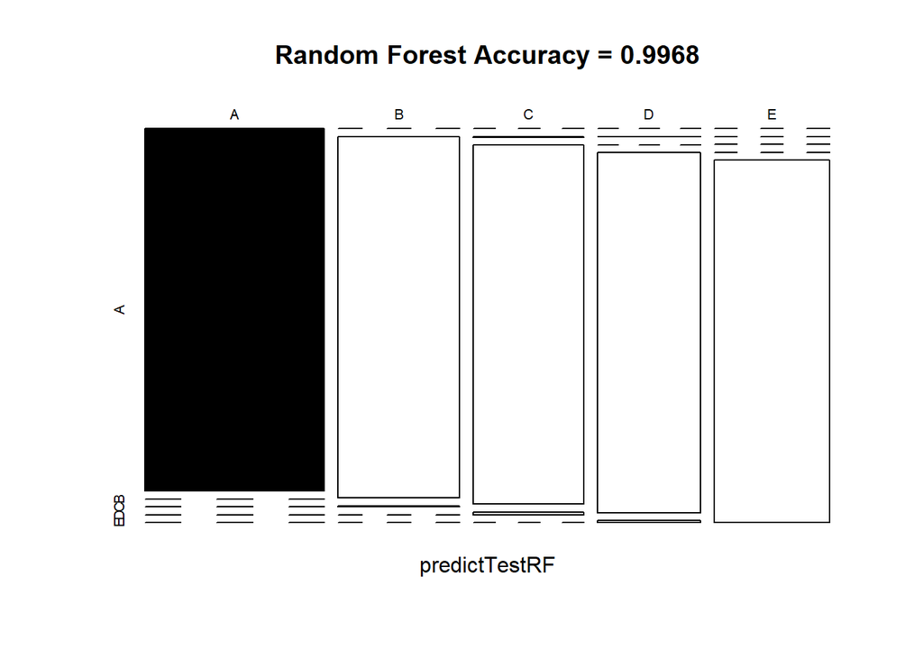

```r
plot(resultRF$table, col = resultRF$byClass,  main = paste("Random Forest Accuracy =", round(resultRF$overall['Accuracy'], 4)))
```

```r
fitGbm <- train(classe~., data = training, method = "gbm", trControl = trainControl(method = "repeatedcv", number = 5, repeats = 1))
fitGbm$finalModel
```

```
## A gradient boosted model with multinomial loss function.
## 150 iterations were performed.
## There were 53 predictors of which 53 had non-zero influence.
```

testing on test set

```r
predictTestGbm <- predict(fitGbm, test)
resultGbm <- confusionMatrix(table(predictTestGbm, test$classe))
```

plotting the result

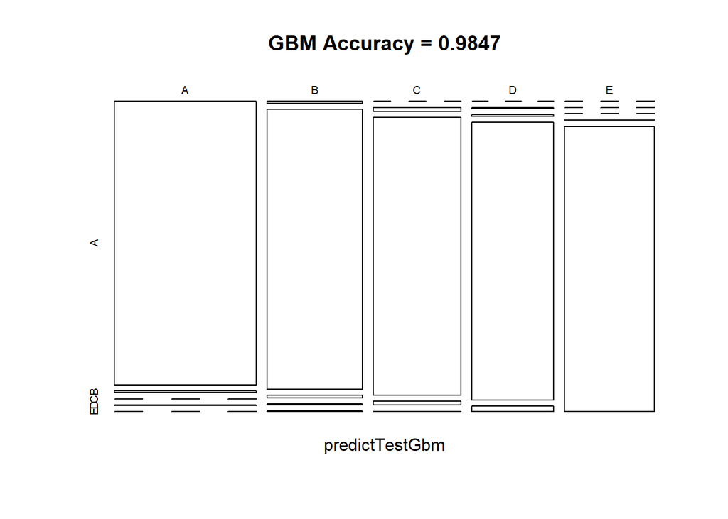

```r
plot(resultGbm$table, col = resultGbm$byClass,  main = paste("GBM Accuracy =", round(resultGbm$overall['Accuracy'], 4)))
```

RF accuracy is better. Hence, applying the fitRF model to validation set

```r
predictVal <- predict(fitRF, validation)
predictVal
```

```
##  [1] B A B A A E D B A A B C B A E E A B B B
## Levels: A B C D E
```